# ハイパフォーマー予測

北川梨津

1/27/2020

## データの読み込み

サンプルデータを読み込んでください．

`naitei`が内定したかどうかを表すダミー変数です．`naitei = 0`なら，不採用となった人ということです．

`high_performer`がハイパフォーマーかどうかを表すダミー変数です．不採用者のパフォーマンスはわからないので，`naitei = 0`となっている人は`high_performer`が`NA`になっていることを確認してください．

```r
df <- read.csv("sampledata.csv")

head(df)
##   X       spi1       spi2       spi3      spi4      spi5      spi6       spi7
## 1 1 -18.793614  34.048953 -26.584488  22.17345 -34.03891 -45.49120 -18.564812
## 2 2   5.509300  33.357955 -57.667647  11.59826  22.93671  18.87424 -33.282659
## 3 3 -25.068858 -26.123329  48.591022  38.89192  17.12130 -50.34582 -65.110057
## 4 4  47.858424   6.321948  15.578097 -24.10675 -40.55082  35.39343  -0.939092
## 5 5   9.885233   2.081869  -1.675498 -48.07877 -60.89656  33.52964  -7.811954
## 6 6 -24.614052 -49.879466  20.892528  27.99753  17.71436 -37.13208  16.032914
##         spi8       spi9      spi10     spi11      spi12 female stem grad naitei
## 1 -39.762532   7.911102 -36.513602 -24.12995 -42.345656      0    0    1      0
## 2  28.559392 -24.883555 -28.386878 -31.69577  32.516090      1    1    0      1
## 3  25.800132 -43.849043   2.742294 -31.06187  35.106671      1    1    1      0
## 4  31.823709  50.519705  21.040538 -35.56681   8.842636      0    0    1      1
## 5 -10.517519 -46.329729  20.202671 -15.01319 -16.632830      1    1    1      0
## 6  -3.922967  -5.726614  37.966601 -15.74966 -12.103221      0    1    1      1
##   high_performer
## 1             NA
## 2              0
## 3             NA
## 4              1
## 5             NA
## 6              1
```

### サブセッティング

内定者だけに絞って分析するために内定者だけのデータフレームをつくります．

```r
naiteisha <- subset(df, naitei == 1)
```

## ロジット回帰

ハイパフォーマー分析をロジット回帰で行います．

```r
result <- glm(high_performer ~ spi1 + spi2 + spi3 + spi4 +
                spi5 + spi6 + spi7 + spi8 + spi9 + spi10 +
                spi11 + spi12 + female + stem + grad,
              family = binomial(link = "logit"),
              data = naiteisha)

summary(result)
```

```
##
## Call:
## glm(formula = high_performer ~ spi1 + spi2 + spi3 + spi4 + spi5 +
##     spi6 + spi7 + spi8 + spi9 + spi10 + spi11 + spi12 + female +
##     stem + grad, family = binomial(link = "logit"), data = naiteisha)
##
## Deviance Residuals:
##     Min       1Q   Median       3Q      Max
## -1.9093  -1.1563   0.7743   1.0552   1.7084
##
## Coefficients:
##               Estimate Std. Error z value Pr(>|z|)
## (Intercept) -0.1467189  0.3675885  -0.399  0.68979
## spi1         0.0068488  0.0031499   2.174  0.02968 *
## spi2         0.0068369  0.0031153   2.195  0.02819 *
## spi3         0.0094394  0.0031483   2.998  0.00272 **
## spi4         0.0028760  0.0032972   0.872  0.38307
## spi5         0.0021846  0.0036675   0.596  0.55141
## spi6         0.0040671  0.0038369   1.060  0.28914
## spi7        -0.0013981  0.0038914  -0.359  0.71939
## spi8         0.0008627  0.0044129   0.195  0.84501
## spi9        -0.0008030  0.0033384  -0.241  0.80991
## spi10        0.0001021  0.0033259   0.031  0.97550
## spi11       -0.0036342  0.0034876  -1.042  0.29740
## spi12        0.0082729  0.0031698   2.610  0.00906 **
## female      -0.2838719  0.2949836  -0.962  0.33588
## stem         0.3276931  0.3344736   0.980  0.32722
## grad         0.2710901  0.3265601   0.830  0.40646
## ---
## Signif. codes:  0 '***' 0.001 '**' 0.01 '*' 0.05 '.' 0.1 ' ' 1
##
## (Dispersion parameter for binomial family taken to be 1)
##
##     Null deviance: 662.21  on 480  degrees of freedom
## Residual deviance: 627.05  on 465  degrees of freedom
## AIC: 659.05
##
## Number of Fisher Scoring iterations: 4
```

## ハイパフォーマー予測

`predict(model, data)`関数を用いれば予測値を出すことができます．引数`model`には回帰分析の結果を格納したオブジェクトを指定します．引数`data`には予測をしたいデータフレームを指定します．このとき，回帰分析に用いた変数がデータフレームの列に含まれている必要があります．ここでは，内定者と不採用者がまとまって入っている`df`を引数に指定します．

そして，その予測値に`predicted_performance`という名前をつけて，`df`に格納しましょう

```r
df$predicted_performance <- predict(result, df)
```

## 予測値の分布を見る

`ggplot2`パッケージの`ggplot()`関数と`geom_density()`関数をつかえば，予測値の分布を見やすく作図できます

．`aes()`の中にある`fill`にはグループ分けの基準となる変数を指定します．その変数は，文字列かファクターである必要があります．今回は`aes()`の中で`factor()`を使ってファクターに変換しています．

`geom_density()`の中の`alpha`は，グラフの色の透明さを指定できます(1なら完全に不透明，0なら完全に透明)．見やすい値に調整してください．

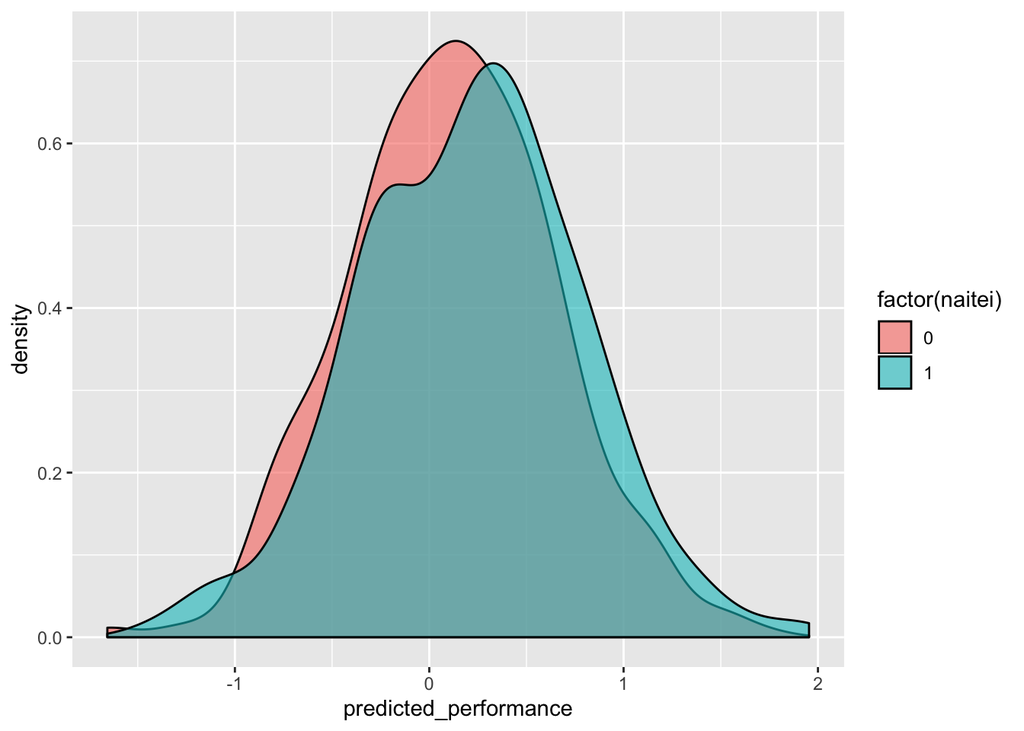

```r
library(ggplot2)

ggplot(data = df, aes(x = predicted_performance, fill = factor(naitei))) +
  geom_density(alpha = 0.6)
```

より見やすくするために次のような工夫をしても良いでしょう．

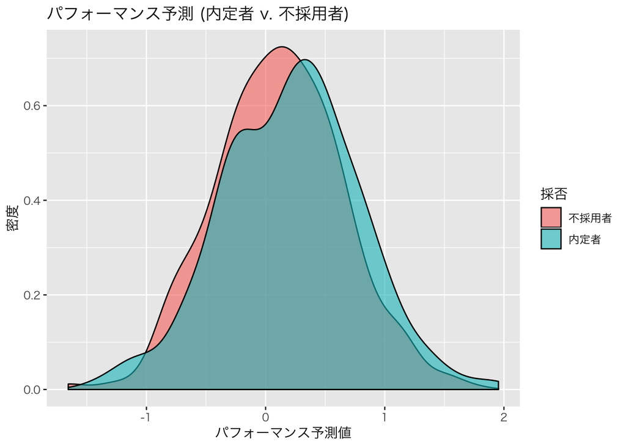

```r
df$採否[df$naitei == 1] <- "内定者"
df$採否[df$naitei == 0] <- "不採用者"

ggplot(data = df, aes(x = predicted_performance, fill = 採否)) +
  geom_density(alpha = 0.6) +
  ggtitle("パフォーマンス予測 (内定者 v. 不採用者)") +
  xlab("パフォーマンス予測値") +
  ylab("密度")
```